# Analytical Hierarchy Process (AHP)

RaumAn4

This is a step-by-step guide corresponding to this week’s lecture.

Patrick Laube , Nils Ratnaweera , Nikolaos Bakogiannis , Dominic Lüönd  
12-06-2021

Now that you have learned the theory, a concrete example of an Analytical Hierarchy Process (AHP) is to be carried out. This is a manual approach to show you the basics of an AHP. If you want to build a more complex AHP you can use specific R AHP packages as shown in the digression section at the end of this script.

## Exercise 1: Define initial situation

First think of an actual decision you are currently facing like buying a bike or a car and define the following points.

- A goal for your AHP (e.g. Buy a bike)
- At least 4 criteria (e.g. price, components, weight, looks)
- At least 3 alternatives (e.g. Scott Genius, Giant XTC, Santa Cruz Megatower C)

## Exercise 2: Pairwise comparison (Paarweiser Vergleich 1 & 2)

In a first step each criterion needs to be compared with another criteria in pairs. Use the following scale for weighting the criteria (see table 1) .

Table 1: Scale for weighting the criteria.

| Rating | Definition |
| --- | --- |
| 1 | Two characteristics are equally important |
| 2 | Between 1 and 3 |
| 3 | The preferred characteristics are slightly more important |
| 4 | Between 3 and 5 |
| 5 | The preferred characteristics are moderately more important |
| 6 | Between 5 and 7 |
| 7 | The preferred characteristics are strongly more important |
| 8 | Between 7 and 9 |
| 9 | The preferred characteristics are absolutely more important |

You can use the following code to create your weighting matrix. In the matrix, two criteria are always compared twice, and these two comparisons should be the reciprocal (“Kehrwert”) of each other. To illustrate this, we have added the comparison for *Criteria 1* compared to *Criteria 2*.

Create this matrix comparison matching your criteria, replacing the `0` values with your weights according to table 1.

```r
pairwise_comparison <- c(
  1,   3, 0, 0,
  1/3, 1, 0, 0,
  0,   0, 1, 0,
  0,   0, 0, 1
) %>% matrix(ncol = 4, byrow = TRUE)
```

```r
# Todo: replace these criteria
# criteria 1: Price
# criteria 2: Distance to work
# criteria 3: Size
# criteria 4: Scenic Beauty
pairwise_comparison <- c(
  1, 7, 3, 1/4,
  1/7, 1, 1/5, 1/7,
  1/3, 5, 1, 1/2,
  4, 7, 2, 1
) %>%
  matrix(ncol = 4, byrow = TRUE)
```

**Tip**: Add column and row names so your matrix is more readable.

```r
criterias <- c("Criteria_1", "Criteria_2","Criteria_3", "Criteria_4")

rownames(pairwise_comparison) <- criterias
colnames(pairwise_comparison) <- criterias
```

## Exercise 3: Calculation of the criteria weights

### Exercise 3.1: Normalization of matrix (Berechnung der Kritiriengewichte 1)

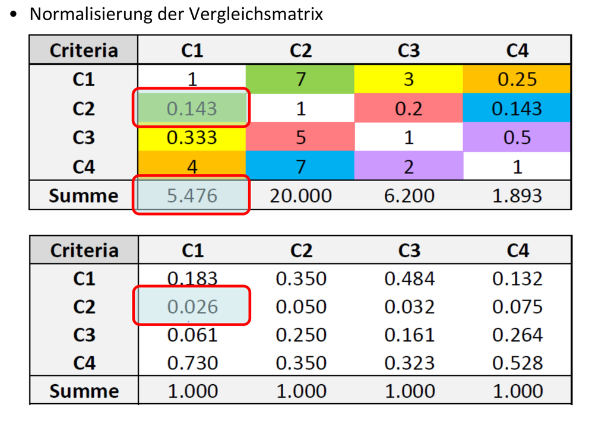

In the next step the matrix needs to be normalized. For that you need to:

1. Calculate the sum of each column using `colSums`. Store the output in a variable (e.g. `ahp_colsums`).
2. Divide each value in the matrix by the corresponding column sum. To achieve this, you can use the `sweep()` function on the matrix, which is very similar to `apply` (`MARGIN = 2` (columns), `STATS = ahp_colsums` and `FUN = "/"`).